# Introduction to Statistics and Machine Learning

Oliver M. Crook

MRC Biostatistics Unit, Cambridge, UK

27 June 2019

#### Abstract

This practical gives a hands on introduction to many of the statistical and machine learning tools used by bioinformaticians. It serves as an introduction and many more advanced topics are omitted. Correction of mistakes and typos is appreciated.

Many of these example have been taken and adapted from

Modern Statistics for Modern Biology; Susan Holmes and Wolfgang Huber

An Introduction to Statistical Learning; James, Witten, Hastie, Tibshirnani

The Elements to Statistical Learning; Friedman, Tibshirani, Hastie

# 1 Testing

## 1.1 Is my coin biased?

The following code chunk simulates 100 coin toss from a biased coin.

```r
set.seed(2) # sets a random seed
numFlips = 100
probHead = 0.59
coinFlips = sample(c("H", "T"), size = numFlips,
  replace = TRUE, prob = c(probHead, 1 - probHead))
head(coinFlips)
```

```
## [1] "H" "T" "H" "H" "T" "T"
```

If the coin were unbiased we expect roughly 50 heads. Let us see how many heads and tails there are.

```r
table(coinFlips)
```

```
## coinFlips
##  H  T
## 62 38
```

We calculate the binomial statistic for a number of flips between 0 and 100. This is the binomial density for an unbiased coin.

```r
library("dplyr")
k = 0:numFlips
numHeads = sum(coinFlips == "H")
binomDensity = tibble(k = k,
     p = dbinom(k, size = numFlips, prob = 0.5))
```

Questions:

1. Write some code to check that the probabilties from the binomial statistic sum to $1$.
2. Change the `prob` argument and show that the probabilities still sum to $1$.

The following code chunk plots the binomial statistic and the number of heads observed is marked in blue.

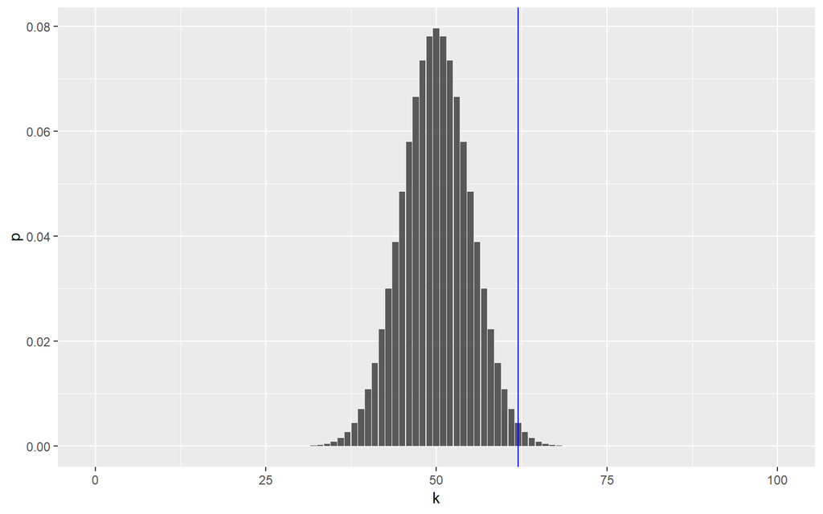

```r
library("ggplot2")
ggplot(binomDensity) +
  geom_bar(aes(x = k, y = p), stat = "identity") +
  geom_vline(xintercept = numHeads, col = "blue")
```

Question:

3. Change the prob argument above and re-plot the binomial statistic, what do you notice about how the distribution is centered?

Now, we set the size of the reject threshold, this is a choice and corresponds to how many false discoveries we are happy to allow.

```r
alpha = 0.05
```

Question:

4. Without looking below use the arrange function from `dplyr` to order the probabilities, smallest first.
5. Looking at the output, what is the most unlikely number of heads to observe?
6. Looking at the output, what is the most likely number of heads to observe?

Solution:

```r
orderBinomDenisty <- arrange(binomDensity, p)
orderBinomDenisty[1,] # most unlikely
```

```
## # A tibble: 1 x 2
##       k        p
##   <int>    <dbl>
## 1     0 7.89e-31
```

```r
orderBinomDenisty[101,]
```

```
## # A tibble: 1 x 2
##       k      p
##   <int>  <dbl>
## 1    50 0.0796
```

Question:

7. What does the following code chunk do?

```r
binomDensity =  arrange(binomDensity, p) %>%
        mutate(reject = (cumsum(p) <= alpha))
```

Let us plot the reject region in red

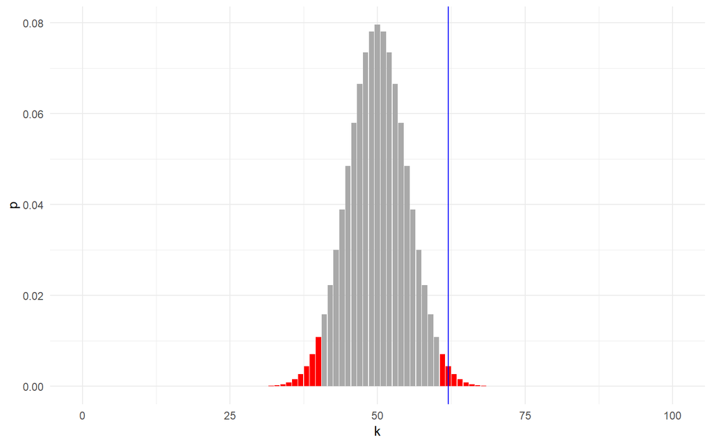

```r
ggplot(binomDensity) +
  geom_bar(aes(x = k, y = p, fill = reject), stat = "identity") +
  scale_fill_manual(
    values = c(`TRUE` = "red", `FALSE` = "darkgrey")) + theme_minimal() +
  geom_vline(xintercept = numHeads, col = "blue") +
  theme(legend.position = "none")
```

Questions:

8. Is there evidence that our coin is biased?
9. Change the size of the reject region to a smaller value, what is our conclusion now?

The above test already has an easy to use funciton in R:

```r
binom.test(x = numHeads, n = numFlips, p = 0.5)
```

```
##
##  Exact binomial test
##
## data:  numHeads and numFlips
## number of successes = 62, number of trials = 100, p-value = 0.02098
## alternative hypothesis: true probability of success is not equal to 0.5
## 95 percent confidence interval:
##  0.5174607 0.7152325
## sample estimates:
## probability of success
##                   0.62
```

## 1.2 The t-test

The following is some plant growth data with 2 treatments. The alpha parameter below has nothing to do with the reject region before. It changes the see-throughness of the points to better visualise overlapping points. Have a go at changing it.

```r
library("ggbeeswarm")
```

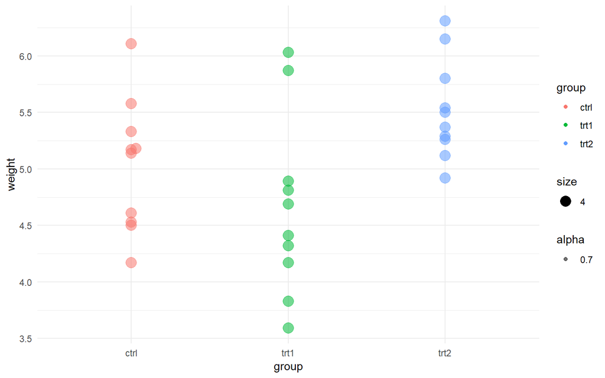

```r
data("PlantGrowth")
ggplot(PlantGrowth, aes(y = weight, x = group, col = group, size = 4, alpha = 0.7)) +
  geom_beeswarm() + theme(legend.position = "none") + theme_minimal()
```

Let us take a look at the PlantGrowth data

```r
head(PlantGrowth)
```

```
##   weight group
## 1   4.17  ctrl
## 2   5.58  ctrl
## 3   5.18  ctrl
## 4   6.11  ctrl
## 5   4.50  ctrl
## 6   4.61  ctrl
```

Question:

10. Using a t-test, check to see whether the difference in means of the ctrl and treatment 1 are different

Solution

```r
t.test(PlantGrowth$weight[PlantGrowth$group == "ctrl"], PlantGrowth$weight[PlantGrowth$group == "trt1"], var.equal = TRUE)
```

```
##
##  Two Sample t-test
##
## data:  PlantGrowth$weight[PlantGrowth$group == "ctrl"] and PlantGrowth$weight[PlantGrowth$group == "trt1"]
## t = 1.1913, df = 18, p-value = 0.249
## alternative hypothesis: true difference in means is not equal to 0
## 95 percent confidence interval:
##  -0.2833003  1.0253003
## sample estimates:
## mean of x mean of y
##     5.032     4.661
```

Questions:

11. What is the p-value?
12. Check the degrees of freedom is correct from the formula?
13. How do the assumptions of the t-test match up with the data?
14. Check the arguments of the t.test function? What happens if you change the equal variance assumption?

You may find the following code useful.

```r
tt = with(PlantGrowth,
          t.test(weight[group =="ctrl"],
                 weight[group =="trt2"],
                 var.equal = TRUE))
tt
```

```
##
##  Two Sample t-test
##
## data:  weight[group == "ctrl"] and weight[group == "trt2"]
## t = -2.134, df = 18, p-value = 0.04685
## alternative hypothesis: true difference in means is not equal to 0
## 95 percent confidence interval:
##  -0.980338117 -0.007661883
## sample estimates:
## mean of x mean of y
##     5.032     5.526
```

### 1.2.1 Optional: Permtutation test example

We briefly talked about permutation tests in the lecture. Here is an example of a permutation test. We determine a null distribution of the statistic by random permutation of the group labels.

```r
abs_t_null = with(
  dplyr::filter(PlantGrowth, group %in% c("ctrl", "trt2")),
    replicate(10000,
      abs(t.test(weight ~ sample(group))$statistic)))
```

Question

15. Why did we use the absolute value function (abs) in the above code?

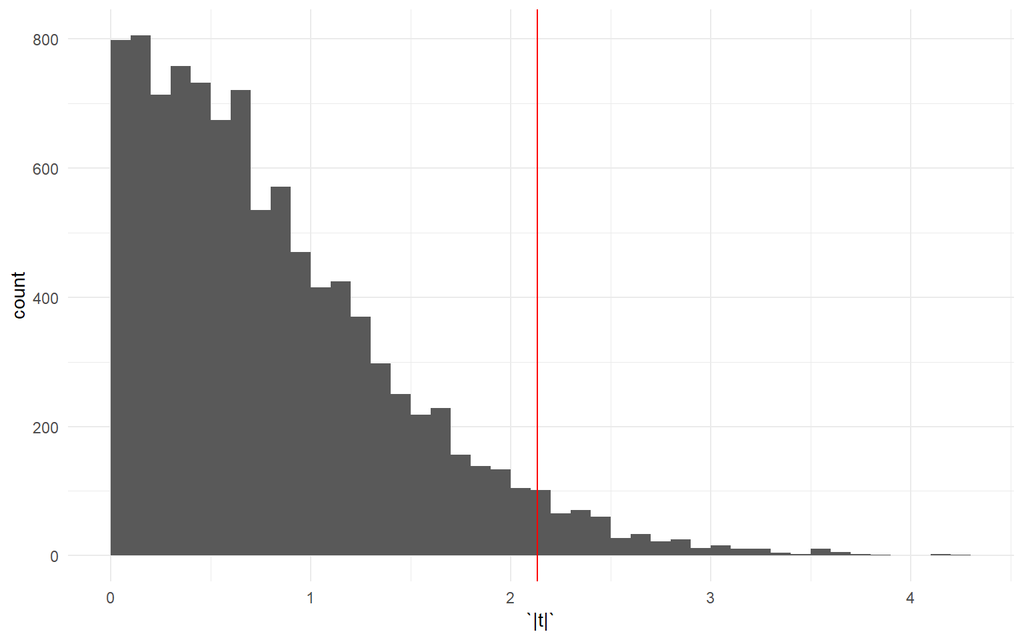

```r
ggplot(tibble(`|t|` = abs_t_null), aes(x = `|t|`)) +
  geom_histogram(binwidth = 0.1, boundary = 0) + theme_minimal() +
  geom_vline(xintercept = abs(tt$statistic), col = "red")
```

The following computes the p-value.

```r
mean(abs(tt$statistic) <= abs_t_null)
```

```
## [1] 0.0454
```

Question

16. Check by writing some code that this value is the same as the rank of the t statistic divided by the number of permutations.
17. Compare the p-value with the one computed using the t-test

# 2 Linear Models

This section discusses linear models. There are many different software packages to work with in R, we start with some simple examples.

Load libraries require for this section.

```r
library(MASS)
library(ISLR)
```

We load the boston housing market dataset, which includes data on the house price values in different neighbourhoods in Boston

```r
data(Boston) # use fix(Boston) to bring up a data editor
names(Boston)
```

```
##  [1] "crim"    "zn"      "indus"   "chas"    "nox"     "rm"      "age"
##  [8] "dis"     "rad"     "tax"     "ptratio" "black"   "lstat"   "medv"
```

In R, the formula syntax is the following `lm(y~x,data)`. The first part specifies the formula of the model (an intercept is included by default) and then the variables to regress on. The second part tells the linear model which data to use. We create a simple linear model with the median values as a reponse and the percent of households with low socioeconomic status (lstat) as a predictor.

```r
lm.fit <- lm(medv ~ lstat , data = Boston) # You need to tell R what data to use
```

The output can be looked at using the summary function. Note how t statistics, R^2 and F statistics, as well as p-values are all outputed automatically. This makes it very easy to apply all the theory we learnt in lectures.

```r
summary(lm.fit)
```

```
##
## Call:
## lm(formula = medv ~ lstat, data = Boston)
##
## Residuals:
##     Min      1Q  Median      3Q     Max
## -15.168  -3.990  -1.318   2.034  24.500
##
## Coefficients:
##             Estimate Std. Error t value Pr(>|t|)
## (Intercept) 34.55384    0.56263   61.41   <2e-16 ***
## lstat       -0.95005    0.03873  -24.53   <2e-16 ***
## ---
## Signif. codes:  0 '***' 0.001 '**' 0.01 '*' 0.05 '.' 0.1 ' ' 1
##
## Residual standard error: 6.216 on 504 degrees of freedom
## Multiple R-squared:  0.5441, Adjusted R-squared:  0.5432
## F-statistic: 601.6 on 1 and 504 DF,  p-value: < 2.2e-16
```

```r
coef(lm.fit) # extract coefficients
```

```
## (Intercept)       lstat
##  34.5538409  -0.9500494
```

```r
confint(lm.fit) # extract confidence intervals
```

```
##                 2.5 %     97.5 %
## (Intercept) 33.448457 35.6592247
## lstat       -1.026148 -0.8739505
```

Question

18. Take the coefficients and calculate the statistics manually (using code not paper!)

We can predict for new values of `lstat`, along with confidence intervals using `predict`

```r
predict(lm.fit ,data.frame(lstat=(c(5,10 ,15))), interval = "confidence")
```

```
##        fit      lwr      upr
## 1 29.80359 29.00741 30.59978
## 2 25.05335 24.47413 25.63256
## 3 20.30310 19.73159 20.87461
```

Let us visualise the results of the linear modelling. What is happening?

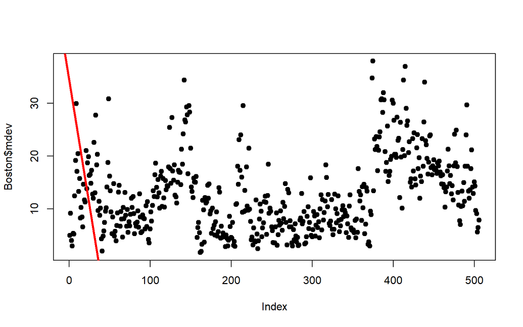

```r
plot(Boston$lstat, Boston$mdev, pch = 19)
abline (lm.fit ,lwd=3,col ="red")
```

Plotting the lm object results in diagnostic plots.

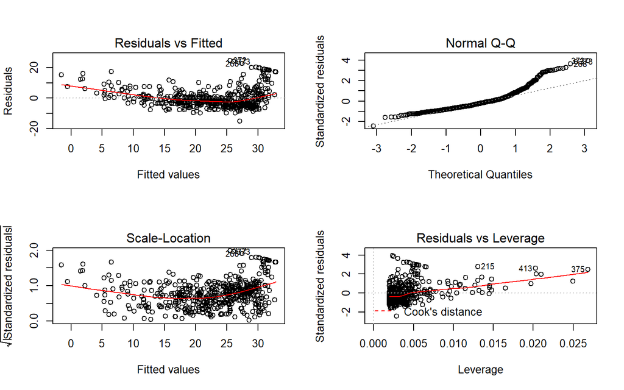

```r
par(mfrow=c(2,2))
plot(lm.fit)
```

## 2.1 Multiple regression

The synatax `lm(y~x1+x2+x3)` is used for multiple linear regression where we are regressing on predictors `x1`, `x2`, `x3` etc. The following example uses `lstat` and `age` to fit a model.

```r
lm.fit <- lm(medv ~ lstat + age , data = Boston )
summary(lm.fit)
```

```
##
## Call:
## lm(formula = medv ~ lstat + age, data = Boston)
##
## Residuals:
##     Min      1Q  Median      3Q     Max
## -15.981  -3.978  -1.283   1.968  23.158
##
## Coefficients:
##             Estimate Std. Error t value Pr(>|t|)
## (Intercept) 33.22276    0.73085  45.458  < 2e-16 ***
## lstat       -1.03207    0.04819 -21.416  < 2e-16 ***
## age          0.03454    0.01223   2.826  0.00491 **
## ---
## Signif. codes:  0 '***' 0.001 '**' 0.01 '*' 0.05 '.' 0.1 ' ' 1
##
## Residual standard error: 6.173 on 503 degrees of freedom
## Multiple R-squared:  0.5513, Adjusted R-squared:  0.5495
## F-statistic:   309 on 2 and 503 DF,  p-value: < 2.2e-16
```

Question

19. Fit at least 5 different linear models using the above synatax? What do you find out?

If we want to use all predictors in the data frame we just put a point, as follows.

```r
lm.fit <- lm(medv~. , data = Boston)
summary (lm.fit)
```

```
##
## Call:
## lm(formula = medv ~ ., data = Boston)
##
## Residuals:
##     Min      1Q  Median      3Q     Max
## -15.595  -2.730  -0.518   1.777  26.199
##
## Coefficients:
##               Estimate Std. Error t value Pr(>|t|)
## (Intercept)  3.646e+01  5.103e+00   7.144 3.28e-12 ***
## crim        -1.080e-01  3.286e-02  -3.287 0.001087 **
## zn           4.642e-02  1.373e-02   3.382 0.000778 ***
## indus        2.056e-02  6.150e-02   0.334 0.738288
## chas         2.687e+00  8.616e-01   3.118 0.001925 **
## nox         -1.777e+01  3.820e+00  -4.651 4.25e-06 ***
## rm           3.810e+00  4.179e-01   9.116  < 2e-16 ***
## age          6.922e-04  1.321e-02   0.052 0.958229
## dis         -1.476e+00  1.995e-01  -7.398 6.01e-13 ***
## rad          3.060e-01  6.635e-02   4.613 5.07e-06 ***
## tax         -1.233e-02  3.760e-03  -3.280 0.001112 **
## ptratio     -9.527e-01  1.308e-01  -7.283 1.31e-12 ***
## black        9.312e-03  2.686e-03   3.467 0.000573 ***
## lstat       -5.248e-01  5.072e-02 -10.347  < 2e-16 ***
## ---
## Signif. codes:  0 '***' 0.001 '**' 0.01 '*' 0.05 '.' 0.1 ' ' 1
##
## Residual standard error: 4.745 on 492 degrees of freedom
## Multiple R-squared:  0.7406, Adjusted R-squared:  0.7338
## F-statistic: 108.1 on 13 and 492 DF,  p-value: < 2.2e-16
```

A minus sign can be use to indicate NOT to use that predictor (it does not do a negative transformation).

```r
lm.fit <- lm(medv ~.-age, data = Boston)
```

## 2.2 Iteraction terms

The syntax to include interaction terms is the following `lstat*age`. The `*` automatically includes the terms `lstat` and `age` as predictors by default.

```r
lm.iteract <- lm(medv ~ lstat * age ,data = Boston)
summary(lm.iteract)
```

```
##
## Call:
## lm(formula = medv ~ lstat * age, data = Boston)
##
## Residuals:
##     Min      1Q  Median      3Q     Max
## -15.806  -4.045  -1.333   2.085  27.552
##
## Coefficients:
##               Estimate Std. Error t value Pr(>|t|)
## (Intercept) 36.0885359  1.4698355  24.553  < 2e-16 ***
## lstat       -1.3921168  0.1674555  -8.313 8.78e-16 ***
## age         -0.0007209  0.0198792  -0.036   0.9711
## lstat:age    0.0041560  0.0018518   2.244   0.0252 *
## ---
## Signif. codes:  0 '***' 0.001 '**' 0.01 '*' 0.05 '.' 0.1 ' ' 1
##
## Residual standard error: 6.149 on 502 degrees of freedom
## Multiple R-squared:  0.5557, Adjusted R-squared:  0.5531
## F-statistic: 209.3 on 3 and 502 DF,  p-value: < 2.2e-16
```

Question

20. Is the iteraction term useful?
21. What can you deduce from the output about these predictors?
22. Look at other iteraction terms, what other predictors have significant interactions?

## 2.3 Non-linear transformations of the predictors

Recall that linear models are *linear in the parameters*. We are allowed to perform non-linear transformation of the predictors as follows. The `I()` is used to preserve standard syntax in R.

```r
lm.nl <- lm(medv ~ lstat + I(lstat^2), data = Boston)
summary(lm.nl)
```

```
##
## Call:
## lm(formula = medv ~ lstat + I(lstat^2), data = Boston)
##
## Residuals:
##      Min       1Q   Median       3Q      Max
## -15.2834  -3.8313  -0.5295   2.3095  25.4148
##
## Coefficients:
##              Estimate Std. Error t value Pr(>|t|)
## (Intercept) 42.862007   0.872084   49.15   <2e-16 ***
## lstat       -2.332821   0.123803  -18.84   <2e-16 ***
## I(lstat^2)   0.043547   0.003745   11.63   <2e-16 ***
## ---
## Signif. codes:  0 '***' 0.001 '**' 0.01 '*' 0.05 '.' 0.1 ' ' 1
##
## Residual standard error: 5.524 on 503 degrees of freedom
## Multiple R-squared:  0.6407, Adjusted R-squared:  0.6393
## F-statistic: 448.5 on 2 and 503 DF,  p-value: < 2.2e-16
```

Question:

21. Try some different transformations of the predictors.

## 2.4 Comparing a linear and non-linear model

```r
lm.linear <-  lm(medv ~ lstat, data = Boston)
lm.nl <- lm(medv ~ lstat + I(lstat^2), data = Boston)
res.anova <- anova(lm.linear, lm.nl)
res.anova
```

```
## Analysis of Variance Table
##
## Model 1: medv ~ lstat
## Model 2: medv ~ lstat + I(lstat^2)
##   Res.Df   RSS Df Sum of Sq     F    Pr(>F)
## 1    504 19472
## 2    503 15347  1    4125.1 135.2 < 2.2e-16 ***
## ---
## Signif. codes:  0 '***' 0.001 '**' 0.01 '*' 0.05 '.' 0.1 ' ' 1
```

Model 1 represents the linear sub-model containing only one predictor, `lstat`, while Model 2 corresponds to the larger quadratic model that has two predictors, `lstat` and `lstat^2`. The anova() function performs a hypothesis test comparing the two models. The null hypothesis is that the two models fit the data equally well, and the alternative hypothesis is that the full model is superior. Here the `F-statistic` is 135 and the associated p-value is virtually zero. This provides very clear evidence that the model containing the predictors `lstat` and `lstat^2` is superior to the model that only contains the predictor `lstat`. This is not surprising, since earlier we saw evidence for non-linearity in the relationship between medv and lstat.

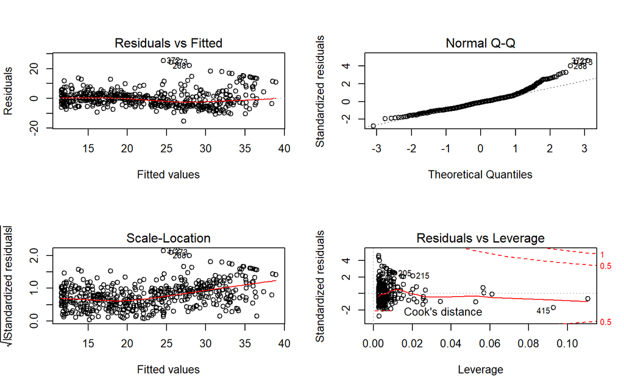

```r
par(mfrow=c(2,2))
plot(lm.nl)
```

## 2.5 Using factors in a linear model

In this section, we explore using factors in a model

```r
data("Carseats")
names(Carseats)
```

```
##  [1] "Sales"       "CompPrice"   "Income"      "Advertising" "Population"
##  [6] "Price"       "ShelveLoc"   "Age"         "Education"   "Urban"
## [11] "US"
```

```r
lm.factor <- lm(Sales~. +Income*Advertising + Price*Age ,data = Carseats )
summary(lm.factor)
```

```
##
## Call:
## lm(formula = Sales ~ . + Income * Advertising + Price * Age,
##     data = Carseats)
##
## Residuals:
##     Min      1Q  Median      3Q     Max
## -2.9208 -0.7503  0.0177  0.6754  3.3413
##
## Coefficients:
##                      Estimate Std. Error t value Pr(>|t|)
## (Intercept)         6.5755654  1.0087470   6.519 2.22e-10 ***
## CompPrice           0.0929371  0.0041183  22.567  < 2e-16 ***
## Income              0.0108940  0.0026044   4.183 3.57e-05 ***
## Advertising         0.0702462  0.0226091   3.107 0.002030 **
## Population          0.0001592  0.0003679   0.433 0.665330
## Price              -0.1008064  0.0074399 -13.549  < 2e-16 ***
## ShelveLocGood       4.8486762  0.1528378  31.724  < 2e-16 ***
## ShelveLocMedium     1.9532620  0.1257682  15.531  < 2e-16 ***
## Age                -0.0579466  0.0159506  -3.633 0.000318 ***
## Education          -0.0208525  0.0196131  -1.063 0.288361
## UrbanYes            0.1401597  0.1124019   1.247 0.213171
## USYes              -0.1575571  0.1489234  -1.058 0.290729
## Income:Advertising  0.0007510  0.0002784   2.698 0.007290 **
## Price:Age           0.0001068  0.0001333   0.801 0.423812
## ---
## Signif. codes:  0 '***' 0.001 '**' 0.01 '*' 0.05 '.' 0.1 ' ' 1
##
## Residual standard error: 1.011 on 386 degrees of freedom
## Multiple R-squared:  0.8761, Adjusted R-squared:  0.8719
## F-statistic:   210 on 13 and 386 DF,  p-value: < 2.2e-16
```

Questions:

22. Which iteractions are significant?
23. Can you explain what the code above mean (write out the model on some paper)?
24. Create some diagnostic plots and visualisations.
25. Which variabes are factors?
26. Create some more models with interaction terms.

The `contrasts` function extracts the coding that was used for the factors.

```r
contrasts(Carseats$ShelveLoc)
```

```
##        Good Medium
## Bad       0      0
## Good      1      0
## Medium    0      1
```

The package `limma` uses similar notation but uses more advanced techniques such as empirical Bayes to improve robustness. These are covered in further praticals.

# 3 Dimensionality Reduction

## 3.1 Principal Components Analysis

We demonstrate principial components analysis using data from US states, which is available in base R.

```r
states <- row.names(USArrests)
states
```

```
##  [1] "Alabama"        "Alaska"         "Arizona"        "Arkansas"
##  [5] "California"     "Colorado"       "Connecticut"    "Delaware"
##  [9] "Florida"        "Georgia"        "Hawaii"         "Idaho"
## [13] "Illinois"       "Indiana"        "Iowa"           "Kansas"
## [17] "Kentucky"       "Louisiana"      "Maine"          "Maryland"
## [21] "Massachusetts"  "Michigan"       "Minnesota"      "Mississippi"
## [25] "Missouri"       "Montana"        "Nebraska"       "Nevada"
## [29] "New Hampshire"  "New Jersey"     "New Mexico"     "New York"
## [33] "North Carolina" "North Dakota"   "Ohio"           "Oklahoma"
## [37] "Oregon"         "Pennsylvania"   "Rhode Island"   "South Carolina"
## [41] "South Dakota"   "Tennessee"      "Texas"          "Utah"
## [45] "Vermont"        "Virginia"       "Washington"     "West Virginia"
## [49] "Wisconsin"      "Wyoming"
```

```r
names(USArrests)
```

```
## [1] "Murder"   "Assault"  "UrbanPop" "Rape"
```

First, looking at the variable means shows that they have very different means.

```r
colMeans(USArrests)
```

```
##   Murder  Assault UrbanPop     Rape
##    7.788  170.760   65.540   21.232
```

The same is true of the variance of the variables

```r
apply(USArrests, 2, var)
```

```
##     Murder    Assault   UrbanPop       Rape
##   18.97047 6945.16571  209.51878   87.72916
```

```r
pr.out <- prcomp(USArrests, scale = TRUE)
```

Let us carefully examine the output of PCA

```r
names(pr.out)
```

```
## [1] "sdev"     "rotation" "center"   "scale"    "x"
```

Question:

27. What are the center and scale variables in the output?

The rotations output provides the princpal component (PC) loadings.

```r
pr.out$rotation
```

```
##                 PC1        PC2        PC3         PC4
## Murder   -0.5358995  0.4181809 -0.3412327  0.64922780
## Assault  -0.5831836  0.1879856 -0.2681484 -0.74340748
## UrbanPop -0.2781909 -0.8728062 -0.3780158  0.13387773
## Rape     -0.5434321 -0.1673186  0.8177779  0.08902432
```

Question:

28. Why are there 4 PCs?

The prcomp function does not require us to compute the scores manually from the loadings. They are stored in `x`

```r
head(pr.out$x)
```

```
##                   PC1        PC2         PC3          PC4
## Alabama    -0.9756604  1.1220012 -0.43980366  0.154696581
## Alaska     -1.9305379  1.0624269  2.01950027 -0.434175454
## Arizona    -1.7454429 -0.7384595  0.05423025 -0.826264240
## Arkansas    0.1399989  1.1085423  0.11342217 -0.180973554
## California -2.4986128 -1.5274267  0.59254100 -0.338559240
## Colorado   -1.4993407 -0.9776297  1.08400162  0.001450164
```

Let us plot the first two PCs. We use the biplot function and the base plot function to demonstrate the differences.

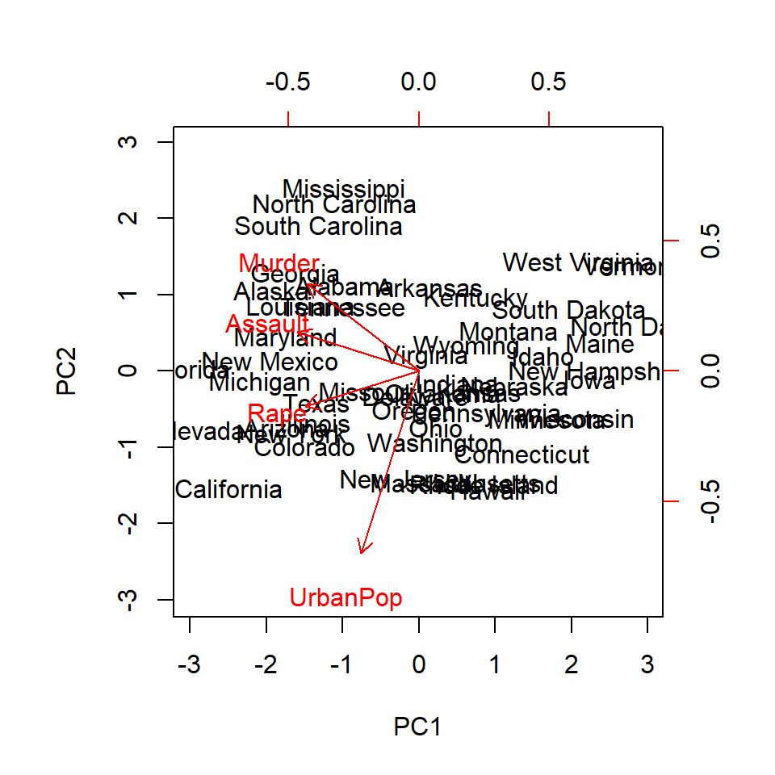

```r
biplot(pr.out, scale = 0)
```

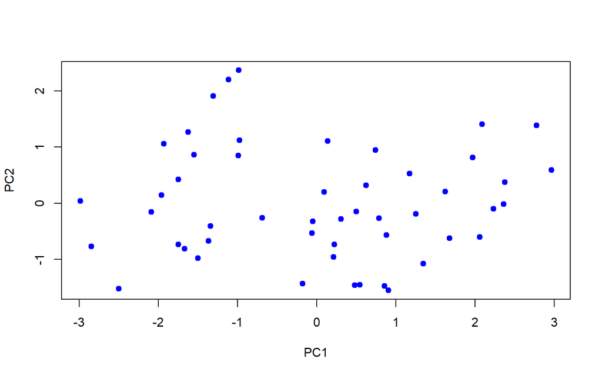

```r
plot(pr.out$x, pch = 19, col = "blue")
```

Unfortunatly, biplot produces a square plot by default. This is, in general, incorrect - the aspect of the plot should be rectangular in proportion to the variances explained.

The variance explained by each component is computed from the standard deviations

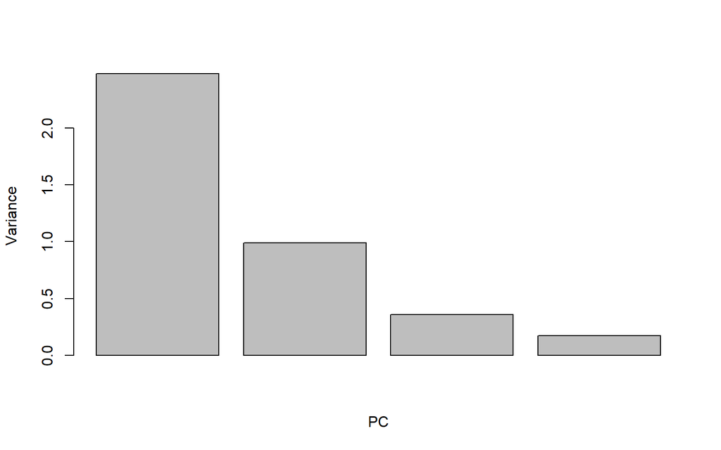

```r
pr.var <- pr.out$sdev ^2
barplot(pr.var, ylab = "Variance", xlab = "PC")
```

The proportion of variance explain can also be easily computed

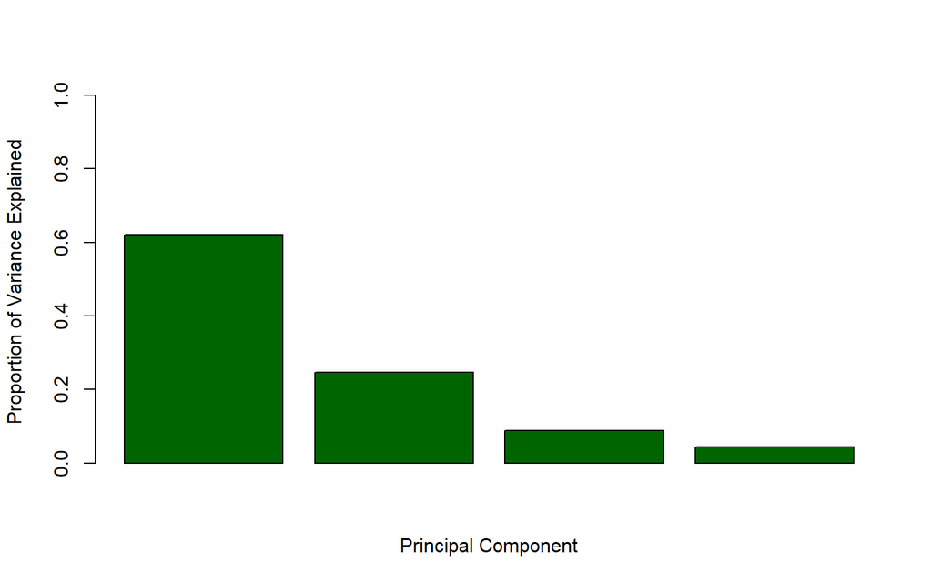

```r
pve <- pr.var/sum(pr.var)
barplot(pve , xlab= "Principal Component", ylab = "Proportion of Variance Explained ", ylim = c(0, 1), col = "darkgreen")
```

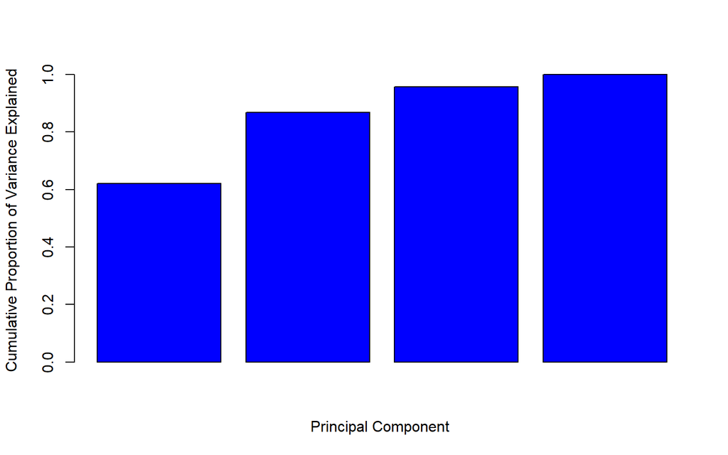

```r
barplot(cumsum(pve), xlab="Principal Component ", ylab = "Cumulative Proportion of Variance Explained ", ylim = c(0, 1), col = "blue")
```

Questions:

29. Use the `princomp` function to perform pca, carefully look at the difference (and defaults!)
30. Using `prcomp` perform pca on the observations rather than the variables by transposing the data matrix.
31. Produce a biplot of this data - what do you notice?

## 3.2 Correspondance Analysis

We demonstrate correspondance Analysis using the Hair and eye colour dataset

```r
maleEyeHair <- HairEyeColor[, , 1]
maleEyeHair
```

```
##        Eye
## Hair    Brown Blue Hazel Green
##   Black    32   11    10     3
##   Brown    53   50    25    15
##   Red      10   10     7     7
##   Blond     3   30     5     8
```

Load the `ca` package

```r
library(ca)
```

The following code chunk performs correspondance analysis.

```r
ca.fit <- ca(maleEyeHair)
```

The followin produces the correspondance analysis plot

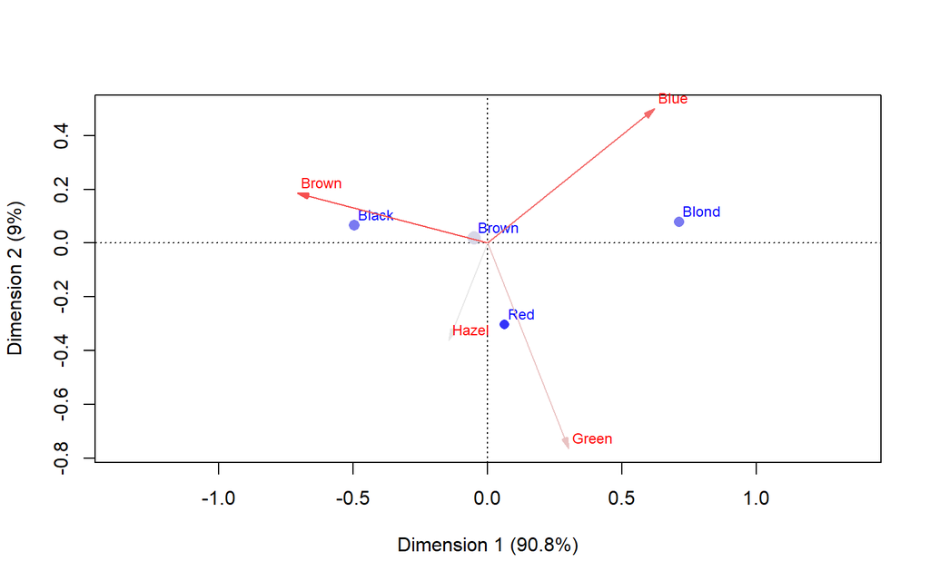

```r
plot(ca.fit, mass = TRUE, contrib = "absolute", map = "rowgreen", arrows = c(FALSE, TRUE))
```

Questions:

32. Change some of the choices above - what does each argument do?
33. Repeat the ca for female eye colour.
34. Perform a chi-squared test on the eye colour dataset. How does this match up with the visualisation in the plot?

# 4 Classification

## 4.1 The k-nearest neighbours method

We use the library `class` and the Smarket dataset. We make predictions on the stock market data by using data from 2001-2004 to then predict for the year 2005.

```r
library(class)
data("Smarket")
```

Create a vector that indicates the years before 2005.

```r
train <- (Smarket$Year < 2005)
```

We use cbind, which is short for column bind to put Lag1 and Lag2 data together and split the data into a training and testing dataset. Note the ! mean not; that is, !train is the opposite of train.

```r
train.X <- cbind(Smarket$Lag1 , Smarket$Lag2)[train, ]
test.X <- cbind(Smarket$Lag1, Smarket$Lag2)[!train, ]
train.Direction <- Smarket$Direction[train]
Direction.2005 <- Smarket$Direction[!train]
```

The k-nearest neighbour algorithm doesn’t need a two-stage model fitting process. By this we mean one to learn the parameters and one to predict. It just predicts. We shall try to predict whether the stock market goes up or down in 2005, at first using $1$ neighbour.

```r
knn.pred <- knn(train.X, test.X, train.Direction , k = 1)
table(knn.pred, Direction.2005)
```

```
##         Direction.2005
## knn.pred Down Up
##     Down   43 58
##     Up     68 83
```

```r
Direction.2005
```

```
##   [1] Down Down Down Up   Down Up   Down Up   Down Up   Up   Down Down Down
##  [15] Down Up   Up   Up   Down Up   Up   Up   Down Up   Down Up   Down Up
##  [29] Up   Up   Up   Up   Down Up   Down Up   Up   Up   Down Up   Down Up
##  [43] Up   Up   Down Down Up   Down Up   Down Down Up   Down Down Down Up
##  [57] Down Up   Down Up   Down Down Up   Up   Up   Up   Down Up   Up   Down
##  [71] Down Down Up   Up   Down Up   Down Up   Down Up   Down Up   Up   Down
##  [85] Up   Down Down Up   Down Up   Down Down Up   Up   Up   Up   Down Up
##  [99] Up   Down Up   Up   Down Up   Up   Down Up   Down Down Up   Down Up
## [113] Up   Up   Up   Up   Down Down Up   Down Down Down Up   Down Down Up
## [127] Up   Down Up   Up   Up   Up   Up   Up   Up   Down Up   Up   Down Up
## [141] Down Up   Up   Up   Down Up   Up   Up   Down Down Down Up   Down Up
## [155] Down Up   Down Up   Down Up   Up   Down Down Up   Down Up   Down Up
## [169] Up   Down Up   Up   Down Up   Down Down Down Up   Up   Down Down Down
## [183] Up   Up   Up   Up   Up   Up   Up   Down Down Down Down Up   Down Down
## [197] Down Down Up   Up   Down Up   Down Up   Up   Down Down Down Up   Up
## [211] Down Up   Up   Up   Up   Down Up   Up   Up   Down Down Up   Up   Up
## [225] Up   Up   Up   Up   Down Up   Down Up   Up   Down Up   Down Down Up
## [239] Up   Up   Up   Down Down Down Down Up   Up   Up   Down Up   Down Down
## Levels: Down Up
```

We now compute how many predictions are correct

```r
(43 + 83)/252
```

```
## [1] 0.5
```

Questions:

35. Repeat the above for different choice of k? What happens?
36. (hard) Can you implement cross-validation to choose k?

## 4.2 Logistic Regression

Next we try to predict the direction of the stock market using logistic regression. The syntax of a generalised linear model `glm()` is the same as for `lm`. However, we need to tell `R` which model to use. In the case of logistic regression, we need to specify a binomial family with logit link (hence the name logistic regression.)

```r
glm.fit <- glm(Direction ~ Lag1 + Lag2 + Lag3 + Lag4 + Lag5 + Volume, data = Smarket, family = binomial(link = "logit") )
summary(glm.fit)
```

```
##
## Call:
## glm(formula = Direction ~ Lag1 + Lag2 + Lag3 + Lag4 + Lag5 +
##     Volume, family = binomial(link = "logit"), data = Smarket)
##
## Deviance Residuals:
##    Min      1Q  Median      3Q     Max
## -1.446  -1.203   1.065   1.145   1.326
##
## Coefficients:
##              Estimate Std. Error z value Pr(>|z|)
## (Intercept) -0.126000   0.240736  -0.523    0.601
## Lag1        -0.073074   0.050167  -1.457    0.145
## Lag2        -0.042301   0.050086  -0.845    0.398
## Lag3         0.011085   0.049939   0.222    0.824
## Lag4         0.009359   0.049974   0.187    0.851
## Lag5         0.010313   0.049511   0.208    0.835
## Volume       0.135441   0.158360   0.855    0.392
##
## (Dispersion parameter for binomial family taken to be 1)
##
##     Null deviance: 1731.2  on 1249  degrees of freedom
## Residual deviance: 1727.6  on 1243  degrees of freedom
## AIC: 1741.6
##
## Number of Fisher Scoring iterations: 3
```

Questions:

37. Extract the coefficients, what do they tell you?
38. Which coefficients seem most useful for prediction?
39. Using the p-values make a prediction about how well the logistic regression model will predict?

To make a prediction we can use the predict function in `R`. The method outputs the probability that the the answer is $1$. Using `contrasts` decided whether $1$ corresponds to up or down in the market.

```r
glm.probs <- predict(glm.fit, type = "response")
glm.probs[1:10]
```

```
##         1         2         3         4         5         6         7
## 0.5070841 0.4814679 0.4811388 0.5152224 0.5107812 0.5069565 0.4926509
##         8         9        10
## 0.5092292 0.5176135 0.4888378
```

To covert these probabilities to predictions we threshold at $0.5$.

```r
glm.pred <- rep("Down" , 1250)
glm.pred[glm.probs > 0.5] <- "Up"
```

To see how well the classification see whether the predictions correspond to the true answers.

```r
table(glm.pred, Smarket$Direction )
```

```
##
## glm.pred Down  Up
##     Down  145 141
##     Up    457 507
```

Question:

40. As was done K-NN compute the accuracy of the method.
41. How well does the answer match your prediction for 39)
42. What does the subset argument do in the glm?
43. Using subset, fit the model only on the training data and test only on the data not used for training.

# 5 Clustering

## 5.1 The K-means algorithm

The `kmeans` function implements the kmeans method in `R`. We simulate some data for which we know there are two clusters and we apply kmeans to these data.

```r
set.seed(2)
x <- matrix(rnorm (50 * 2), ncol = 2)
x[1:25, 1] <- x[1:25, 1] + 3
x[1:25, 2] <- x[1:25, 2] - 4
```

We now apply the kmeans algorithm.

```r
km.out <- kmeans(x, 2, nstart = 20)
```

We see that the clustering recovers the original simulation

```r
km.out$cluster
```

```
##  [1] 2 2 2 2 2 2 2 2 2 2 2 2 2 2 2 2 2 2 2 2 2 2 2 2 2 1 1 1 1 1 1 1 1 1 1 1
## [37] 1 1 1 1 1 1 1 1 1 1 1 1 1 1
```

The following plot visualises the data and clustering.

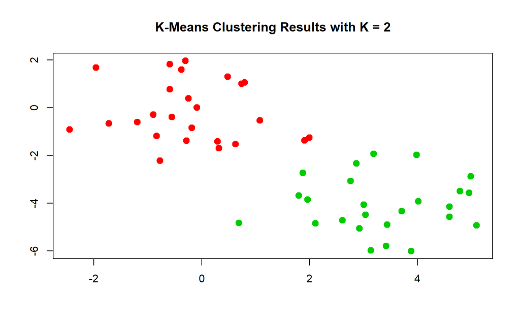

```r
plot(x, col=(km.out$cluster +1), main="K-Means Clustering Results with K = 2", xlab="", ylab="", pch=20, cex=2)
```

Questions:

44. Try kmeans with different values of k
45. How does the within sum of squares change for different values of K?
46. Apply kmeans to either your own dataset or a dataset in this workbook.

## 5.2 Hierarchical clustering

The `hclust` function performs hierarchical clustering in R. An example is the following, which uses complete linkage

```r
hc.complete = hclust(dist(x), method = "complete")
```

Question:

47. By changing the argument for method perform single and average linkage clustering

The plot function allows you to view the dendrograms

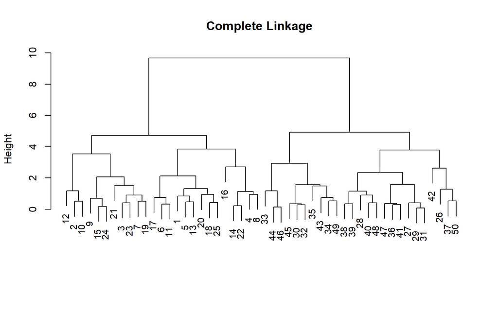

```r
plot(hc.complete, main="Complete Linkage ", xlab="", sub="", cex=.9)
```

Question:

48. Plot the dendrograms for single and average linkage.
49. What are the difference between the methods?

To compute a clustering, we cut the tree. This is performed using the following code

```r
cutree(hc.complete , 2)
```

```
##  [1] 1 1 1 1 1 1 1 1 1 1 1 1 1 1 1 1 1 1 1 1 1 1 1 1 1 2 2 2 2 2 2 2 2 2 2 2
## [37] 2 2 2 2 2 2 2 2 2 2 2 2 2 2
```

Question:

50. Cut the single and average linkage trees?
51. What is the effect of changing the numb of groups?
52. Test hierarchical clustering on your favourite dataset